# Forecast for ORP

### Do we need to adjust the data?

We could compute the average daily counts for weekdays and weekends seperately to create a system that takes day of week into account?

We could use monthly or weekly totals as well for a more general approach to volume.

##### ETS model

RMSE = 610

Wow! Finally a better error than the naive model (689) !

```r
fit.ets <- ets(orp.ts)
```

```
I can't handle data with frequency greater than 24. Seasonality will be ignored. Try stlf() if you need seasonal forecasts.
```

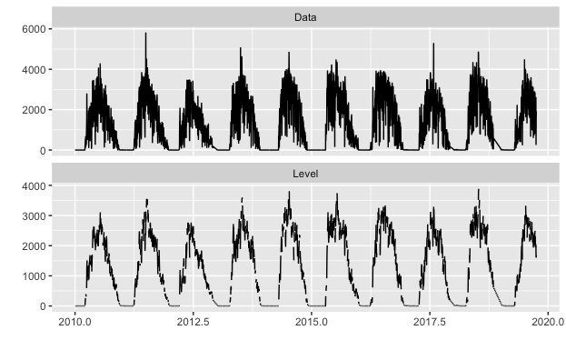

```r
autoplot(fit.ets)
```

```r
summary(fit.ets)
```

```
ETS(A,N,N)

Call:
 ets(y = orp.ts)

  Smoothing parameters:
    alpha = 0.2219

  Initial states:
    l = -9e-04

  sigma:  609.5886

     AIC     AICc      BIC
74774.98 74774.99 74793.51

Training set error measures:
                   ME     RMSE      MAE MPE MAPE     MASE      ACF1
Training set 2.131923 609.4173 380.2928 NaN  Inf 0.671518 0.2103026
```

```
    Ljung-Box test

data:  Residuals from ETS(A,N,N)
Q* = 9225.7, df = 710, p-value < 2.2e-16

Model df: 2.   Total lags used: 712
```

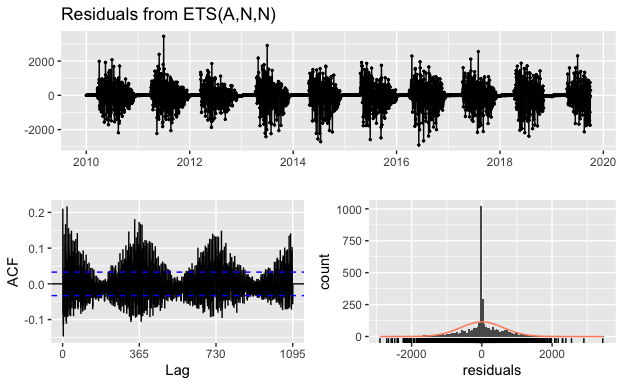

```r
checkresiduals(fit.ets)
```

Still lots of autocorrelation to incorporate into the model? Weekly autocorrelation..?

For diff’ed data; sigma is 689.

```r
fit.ets <- ets(orp.diff)
```

```
I can't handle data with frequency greater than 24. Seasonality will be ignored. Try stlf() if you need seasonal forecasts.
```

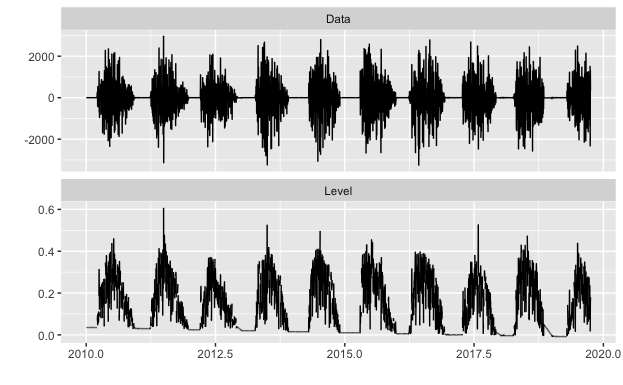

```r
autoplot(fit.ets)
```

```r
summary(fit.ets)
```

```
ETS(A,N,N)

Call:
 ets(y = orp.diff)

  Smoothing parameters:
    alpha = 1e-04

  Initial states:
    l = 0.0354

  sigma:  689.2804

     AIC     AICc      BIC
75627.52 75627.53 75646.05

Training set error measures:
                    ME     RMSE      MAE MPE MAPE      MASE       ACF1
Training set 0.4075591 689.0867 407.2934 NaN  Inf 0.6900046 -0.2923796
```

```
    Ljung-Box test

data:  Residuals from ETS(A,N,N)
Q* = 3437.5, df = 710, p-value < 2.2e-16

Model df: 2.   Total lags used: 712
```

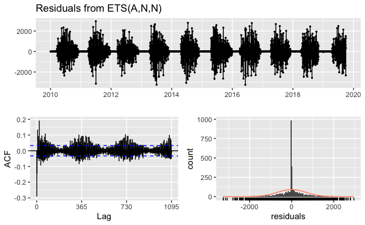

```r
checkresiduals(fit.ets)
```

##### STL + ETS model

- provide insight into structure of time series patterns “Forecasting Using Stl Objects Forecasts of STL objects are obtained by applying a non-seasonal forecasting method to the seasonally adjusted data and re-seasonalizing using the last year of the seasonal component.”
- Maximum likelihood/Kalman filter creates fit
- can inject priors on parameters (Bayesian framework)
- can be expressed in arima terms of ar and ma.

STL + ETS(A,N,N) gives RMSE = 547; much better than just ets()…

```r
fit.stl <- stlf(orp.ts)
summary(fit.stl)
```

```
Forecast method: STL +  ETS(A,N,N)

Model Information:
ETS(A,N,N)

Call:
 ets(y = na.interp(x), model = etsmodel, allow.multiplicative.trend = allow.multiplicative.trend)

  Smoothing parameters:
    alpha = 0.0979

  Initial states:
    l = 1171.6665

  sigma:  547.7174

     AIC     AICc      BIC
74012.96 74012.97 74031.50

Error measures:
                    ME     RMSE      MAE MPE MAPE      MASE     ACF1
Training set -0.200635 547.5635 352.5926 NaN  Inf 0.6226053 0.267485

Forecasts:
```

|  | Point Forecast | Lo 80 | Hi 80 | Lo 95 | Hi 95 |
| --- | --- | --- | --- | --- | --- |
| 2019.7534 | 1597.0206771 | 895.092566 | 2298.9488 | 523.514270 | 2670.527 |
| 2019.7562 | 1260.5786109 | 555.296344 | 1965.8609 | 181.942465 | 2339.215 |
| 2019.7589 | 1483.4342898 | 774.813743 | 2192.0548 | 399.692685 | 2567.176 |
| 2019.7616 | 1458.9994484 | 747.056275 | 2170.9426 | 370.176324 | 2547.823 |
| 2019.7644 | 1590.0508391 | 874.800474 | 2305.3012 | 496.169801 | 2683.932 |
| 2019.7671 | 1384.0410499 | 665.498714 | 2102.5834 | 285.125378 | 2482.957 |
| 2019.7699 | 1241.6705671 | 519.851274 | 1963.4899 | 137.743222 | 2345.598 |
| 2019.7726 | 795.4993597 | 70.417919 | 1520.5808 | -313.417009 | 1904.416 |
| 2019.7753 | 1123.8698634 | 395.540887 | 1852.1988 | 9.986816 | 2237.753 |
| 2019.7781 | 1321.2767603 | 589.714664 | 2052.8389 | 202.449083 | 2440.104 |

[output cut: 720 more lines]

```
    Ljung-Box test

data:  Residuals from STL +  ETS(A,N,N)
Q* = 10220, df = 710, p-value < 2.2e-16

Model df: 2.   Total lags used: 712
```

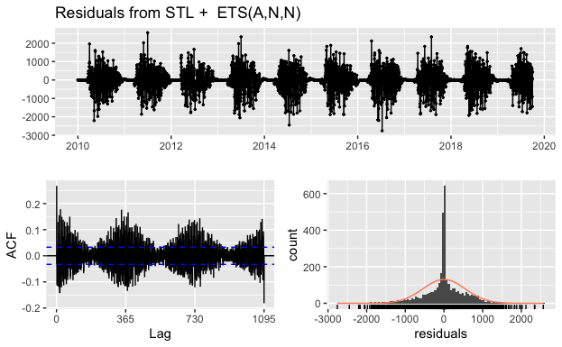

```r
checkresiduals(fit.stl)
```

#### Train and compare to test data

```r
train <- ORP[, c(1,2)] %>%
  filter(year(Date) < 2017) %>%
  as_tsibble()
test <- ORP[, c(1,2)] %>%
  filter(year(Date) >= 2017) %>%
  as_tsibble()

train1 <- ts(ORP[,c(2)], start = c(2010,01,01), end = c(2016,12,31), deltat = 1/365)
test1 <- ts(ORP[,c(2)], start = c(2017,01,01), deltat = 1/365)
# train1 <- window(train1, start = c(2010,01))
```

```r
orp_fit <- stlf(orp.ts, h=400)

# %>%
#   model("stlf" = snaive(y=count))
# orp_fc <- orp_fit %>% forcast(h=500)
# orp.stlf <- augment(orp_fit)
```

#### Notes

Arima doesn’t work on daily data. It struggles with large datasets, runs out of memory eventually.

So not good if we want to keep daily data and use the weekly trend for predicting daily volume.

We could summarise by monthly totals are run auto.arima on that for fun to see next year for ORP…

```
fit.arima <- auto.arima(orp.ts, stepwise = TRUE, approximation = TRUE, trace = TRUE)
summary(fit.arima)
checkresiduals(fit.arima)
```

#### Time-aware diagnostics

```r
ljung_box(orp$count)
```

```
  lb_stat lb_pvalue
 2534.724     0.000
```

```r
ljung_box(orp$diff)
```

[output not shown]

### Structural Time Series

## Stationarity

## Cross-validation?

## Look ahead

## Review Goals

Broadly speaking, we can do three things with an effective model of the time series…  
- **smoothing**: fix data in the past that may have been erroneously measured/timed.  
- there are some gaps in the counters data due to construction/instrument failure - we could further improve our models later by removing erroneous data and adding simulated data. - this has alredy been done for certain periods, we could compare our smoothing with the city’s previous work and visualize. - **filtering**: is the current data reasonable; is the instrument broken?  
- this would be a step further; could be done with realish-time updates from Laurier/Met. - **forecasting**: predict traffic levels in the future from available data.  
- possibly has the most or least value depending on the model accuracy.

### things that don’t work

-shannon entropy/ information content: needs none existent ForeCA package not on CRAN

```r
# shannon <- bikes %>%
  # features(count, feat_spectral)

# feat_spectral(orp)
```